# Final Project

Yanfei Zhao

2021/12/8

Acknowledgements: The data source I used in this project is 2015 World Happiness Report downloaded from https://www.kaggle.com/datasnaek/youtube-new?select=CAvideos.csv.

# GETTING STARTED

In this report, there are multiple variables contributing to the citizens happiness level jointly, but I tend to emphasize on the relationship between country economy and the happiness and simplify the analysis process.

## Import the dataset and tidy the data

```r
WHR <- read_csv('/Users/apple/downloads/WHR.csv')
```

```
## ─ Column specification ────────────────────────────
```

```r
WHR
```

```
## # A tibble: 158 × 12
##    Country     Region         `Happiness Rank` `Happiness Scor… `Standard Error`
##    <chr>       <chr>                     <dbl>            <dbl>            <dbl>
##  1 Switzerland Western Europe                1             7.59           0.0341
##  2 Iceland     Western Europe                2             7.56           0.0488
##  3 Denmark     Western Europe                3             7.53           0.0333
##  4 Norway      Western Europe                4             7.52           0.0388
##  5 Canada      North America                 5             7.43           0.0355
##  6 Finland     Western Europe                6             7.41           0.0314
##  7 Netherlands Western Europe                7             7.38           0.0280
##  8 Sweden      Western Europe                8             7.36           0.0316
##  9 New Zealand Australia and…                9             7.29           0.0337
## 10 Australia   Australia and…               10             7.28           0.0408
## # … with 148 more rows, and 7 more variables: Economy (GDP per Capita) <dbl>,
## #   Family <dbl>, Health (Life Expectancy) <dbl>, Freedom <dbl>,
## #   Trust (Government Corruption) <dbl>, Generosity <dbl>,
## #   Dystopia Residual <dbl>
```

```r
colnames(WHR)[6] <- "Economy_GDP_per_Capita"
colnames(WHR)[4] <- "Happiness.Score"
```

# BASIC ANALYSIS

## Variables

I would like to pick a couple of explanatory variables of interest: GDP per capita & happiness score in different regions.

```r
world_happiness <- WHR %>%
  select(Economy_GDP_per_Capita, Happiness.Score, Region)
```

## Get some summary numbers

Using summary() function to get some summary information here.

```r
world_happiness %>% summary(
  mean_economy = mean(Economy_GDP_per_Capita, na.rm=TRUE),
  sd_economy = sd(Economy_GDP_per_Capita, na.rm = TRUE)
)
```

```
##  Economy_GDP_per_Capita Happiness.Score    Region
##  Min.   :0.0000         Min.   :2.839   Length:158
##  1st Qu.:0.5458         1st Qu.:4.526   Class :character
##  Median :0.9102         Median :5.232   Mode  :character
##  Mean   :0.8461         Mean   :5.376
##  3rd Qu.:1.1584         3rd Qu.:6.244
##  Max.   :1.6904         Max.   :7.587
```

## Make a Box graph

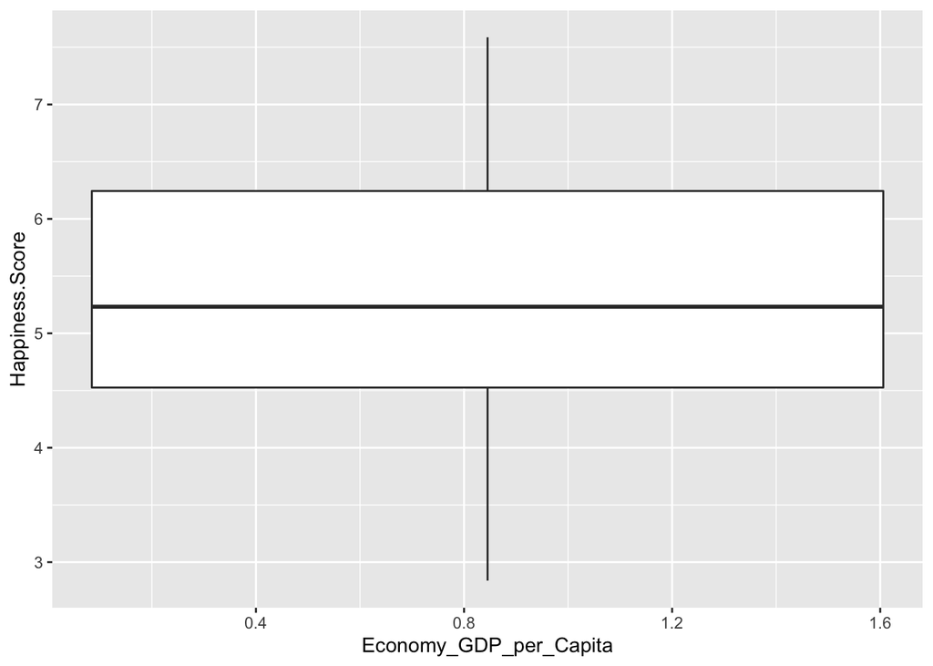

```r
ggplot(world_happiness, aes(x=Economy_GDP_per_Capita,y=Happiness.Score))+
  geom_boxplot()
```

## Make a histogram of the Economy

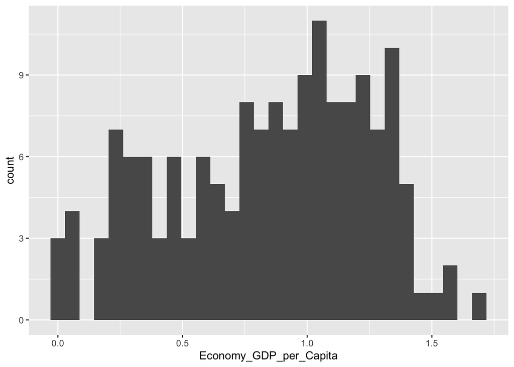

```r
ggplot(world_happiness, aes(x=Economy_GDP_per_Capita)) +
  geom_histogram()
```

## And happiness score

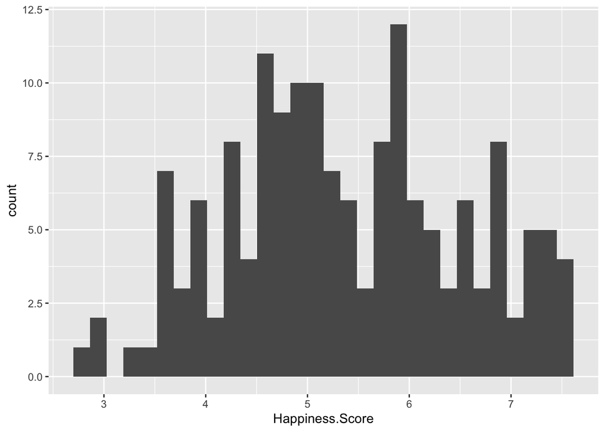

```r
ggplot(world_happiness, aes(x=Happiness.Score))+
  geom_histogram()
```

## And region

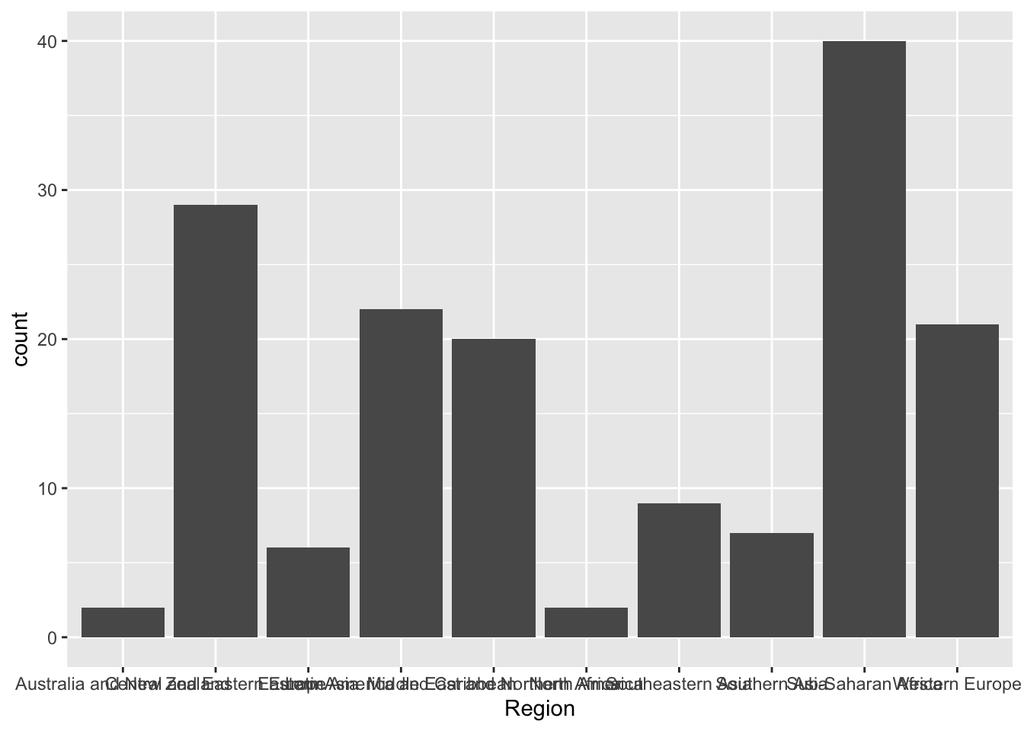

```r
ggplot(world_happiness, aes(x=Region))+
  geom_histogram(stat="count")
```

### I found

Sub-Saharan Africa has the largest number of countries, and most countries’ happiness score is less than 6 and most countries GDP is less than 1.0 in the world.

# MULTIVARIATE EXPLORATORY DATA ANALYSIS

## Plot interaction model

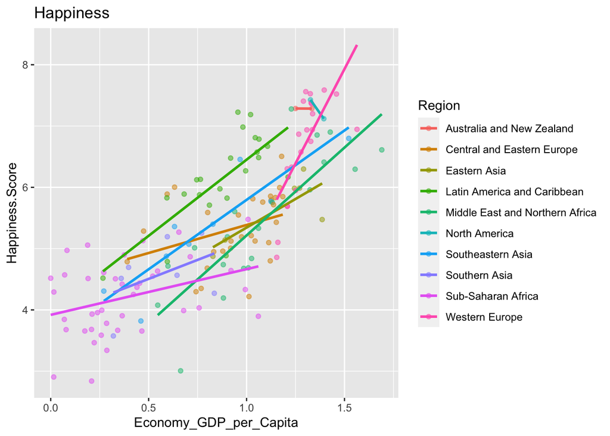

```r
ggplot(world_happiness,
       aes(x = Economy_GDP_per_Capita, y = Happiness.Score, col = Region)) +
  geom_point(alpha = 0.5) +
  geom_smooth(method = "lm", se = FALSE) +
  labs(y = "Happiness.Score",
       x = "Economy_GDP_per_Capita",
       title = "Happiness")
```

## The parallel slopes model

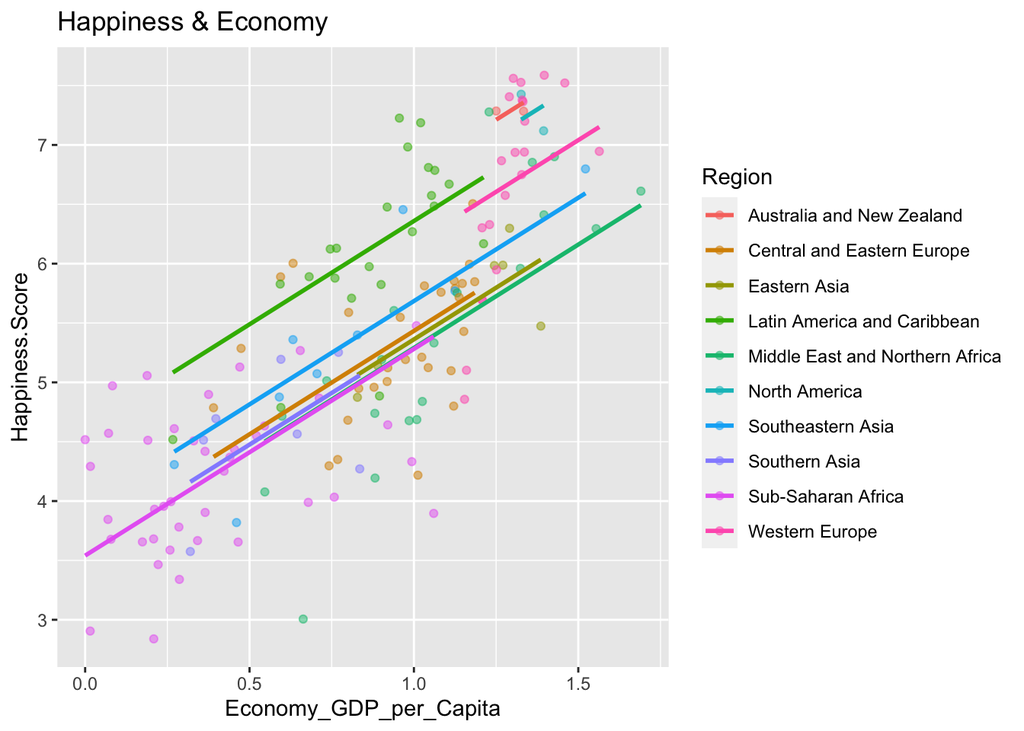

```r
ggplot(world_happiness,
       aes(x = Economy_GDP_per_Capita, y = Happiness.Score, col = Region)) +
  geom_point(alpha = 0.5) +
  geom_parallel_slopes(se = FALSE) +
  labs(y = "Happiness.Score",
       x = "Economy_GDP_per_Capita",
       title = "Happiness & Economy")
```

## Analyze in the different angles in terms of regions

### Get some summary numbers using group by function

```r
world_happiness <- world_happiness %>%
  group_by(Region) %>%
  summarize(mean_score = mean(Happiness.Score, na.rm = TRUE),
            sd_score = sd(Happiness.Score, na.rm = TRUE))
world_happiness
```

```
## # A tibble: 10 × 3
##    Region                          mean_score sd_score
##    <chr>                                <dbl>    <dbl>
##  1 Australia and New Zealand             7.28  0.00141
##  2 Central and Eastern Europe            5.33  0.570
##  3 Eastern Asia                          5.63  0.554
##  4 Latin America and Caribbean           6.14  0.729
##  5 Middle East and Northern Africa       5.41  1.10
##  6 North America                         7.27  0.218
##  7 Southeastern Asia                     5.32  0.950
##  8 Southern Asia                         4.58  0.571
##  9 Sub-Saharan Africa                    4.20  0.610
## 10 Western Europe                        6.69  0.825
```

### I found

Australia and New Zealand have the highest mean happiness score in the world and Western Europe is the third one.

## Visualize the summary date though a Boxplot with individual data points

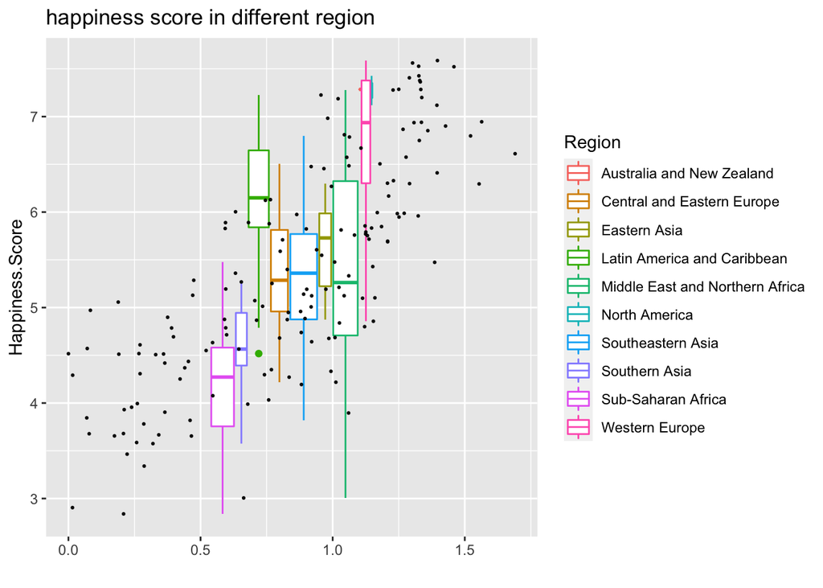

```r
world_happiness <- WHR
ggplot(world_happiness,
       aes(x = Economy_GDP_per_Capita, y = Happiness.Score, col = Region)) +
  geom_boxplot() +
  scale_fill_viridis(discrete = TRUE, alpha=0.6) +
  geom_jitter(color='black', size=0.4, alpha=0.9) +
  ggtitle("happiness score in different region") +
  xlab("")
```

(Reference https://www.r-graph-gallery.com/89-box-and-scatter-plot-with-ggplot2.html)

### I found

Through the boxplot, I can tell that most the countries in Western Europe, Eastern Asia, Southeastern Asia have beyond the average happiness score in respective regions.

```r
happiness_model <- lm( Happiness.Score~ Economy_GDP_per_Capita,
                     data = world_happiness)
```

## View the model coefficients with get_regression_table()

```r
get_regression_table(happiness_model)
```

```
## # A tibble: 2 × 7
##   term                   estimate std_error statistic p_value lower_ci upper_ci
##   <chr>                     <dbl>     <dbl>     <dbl>   <dbl>    <dbl>    <dbl>
## 1 intercept                  3.50     0.133      26.3       0     3.24     3.76
## 2 Economy_GDP_per_Capita     2.22     0.142      15.6       0     1.94     2.50
```

This looks really simple regression which is “happiness score ~ intercept + Economy_GDP_per_Capita” that is 3.50 + 2.22 * Economy_GDP_per_Capita

## Visualize the model

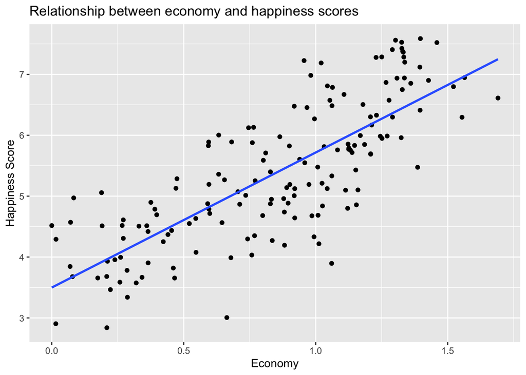

```r
ggplot(happiness_model, aes(x = Economy_GDP_per_Capita, y = Happiness.Score)) +
  geom_point() +
  labs(x = "Economy", y = "Happiness Score",
       title = "Relationship between economy and happiness scores") +
  geom_smooth(method = "lm", se = FALSE)
```

# CONCLUSION

In a nutshell, the relationship between Economy and Human Happiness is corresponding to our common sense which is positive relevance.

## The tasks I completed:

1. Visualize the dataset and analysis results using at least 2 different chart types.
2. Report descriptive statistics about the dataset and explain what they tell us.
3. Wrangle the data using any of the data wrangling functions covered in class.
4. Fit a linear model